# Übung 1 - Recap

## Übung 2 (3 Punkte)

Teile die Daten in Trainings- und Testsets auf. Berücksichtige ein 70:30 Verhältnis zwischen den Sets.

```r
split<- createDataPartition(churn$Churn, p=0.7, list=F)
churn_train <- churn[split,]
churn_test <-  churn[-split,]
length(churn$Churn)
```

```
## [1] 7032
```

```r
length(churn_train$Churn)
```

```
## [1] 4924
```

```r
length(churn_test$Churn)
```

```
## [1] 2108
```

## Übung 3 (3 Punkte)

Stelle auf ein KNN Modell mit der Funktion Train. Wähle den richtigen Algorithmus dafür. Prognostiziere Ergebnisse mit den Testdaten. Stelle auf eine Confusion Matrix (Funktion confusionMatrix) auf.

```r
churn_knn <- train(Churn~., data = churn_train, method = "knn")
churn_knn
```

```
## k-Nearest Neighbors
##
## 4924 samples
##   19 predictor
##    2 classes: 'No', 'Yes'
##
## No pre-processing
## Resampling: Bootstrapped (25 reps)
## Summary of sample sizes: 4924, 4924, 4924, 4924, 4924, 4924, ...
## Resampling results across tuning parameters:
##
##   k  Accuracy   Kappa
##   5  0.7437629  0.3284393
##   7  0.7549426  0.3473100
##   9  0.7612431  0.3563270
##
## Accuracy was used to select the optimal model using the largest value.
## The final value used for the model was k = 9.
```

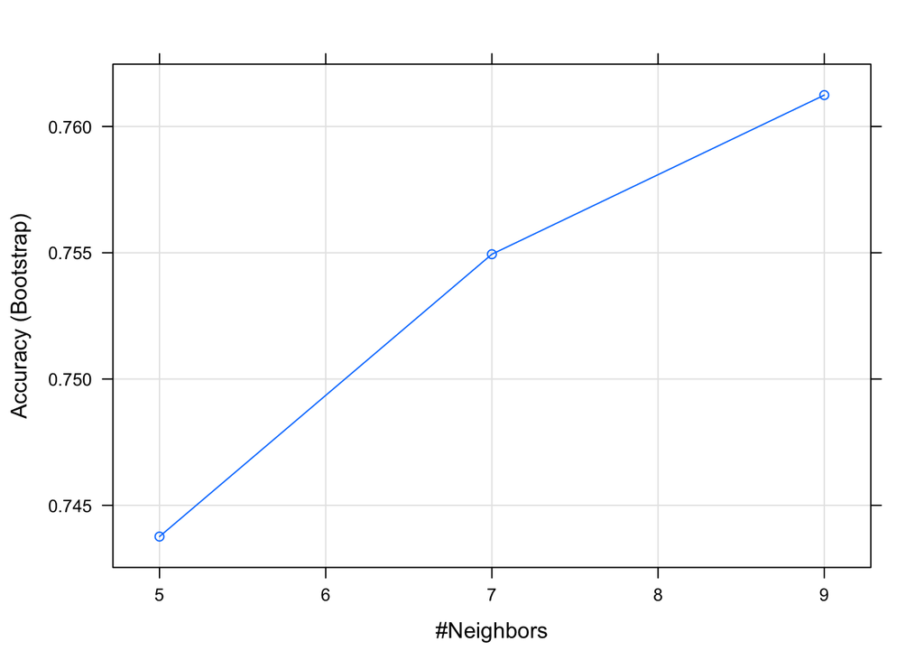

```r
plot(churn_knn)
```

Prognostiziere Ergebnisse mit den Testdaten

```r
pred_knn <- predict(churn_knn, newdata = churn_test)
mean(pred_knn == churn_test$Churn)
```

```
## [1] 0.7874763
```

Berechne Modell-Accuracy mit der Funktion confusionMatrix

```r
conf_matrix_knn <- confusionMatrix(pred_knn, churn_test$Churn)
conf_matrix_knn
```

```
## Confusion Matrix and Statistics
##
##           Reference
## Prediction   No  Yes
##        No  1378  278
##        Yes  170  282
##
##                Accuracy : 0.7875
##                  95% CI : (0.7694, 0.8048)
##     No Information Rate : 0.7343
##     P-Value [Acc > NIR] : 9.284e-09
##
##                   Kappa : 0.4196
##
##  Mcnemar's Test P-Value : 4.298e-07
##
##             Sensitivity : 0.8902
##             Specificity : 0.5036
##          Pos Pred Value : 0.8321
##          Neg Pred Value : 0.6239
##              Prevalence : 0.7343
##          Detection Rate : 0.6537
##    Detection Prevalence : 0.7856
##       Balanced Accuracy : 0.6969
##
##        'Positive' Class : No
##
```

## Übung 4 (3 Punkte)

Versuchen wir die KNN Schaetzung zu verbessern in dem wir Resampling anwenden: Vorhandene Resamplingmethoden sind boot, boot632, cv, LOOCV, LGOCV, repeatedcv and oob. Default ist boot. LOOCV, LGOCV sind sehr rechenintensiv. Das Resampling wird mit der Funktion trainControl angewendet.

- Die Resamplingmethode soll repeated CV sein mit k=10 und repeats=3. Wende in der Funktion train auch die Datenskalierung mit dem Argument “preProcess” an.
- Prognostiziere Ergebnisse mit den Testdaten.
- Stelle auf eine Confusion Matrix (Funktion confusionMatrix) auf.

```r
ctrl <- trainControl(method="repeatedcv", repeats = 3)
churn_knn_tuned <- train(Churn~., data = churn_train, method = "knn", tuneLength = 10, trControl = ctrl, preProcess = c("center","scale"))
```

Prognostiziere Ergebnisse mit den Testdaten

```r
pred_knn_tuned <- predict(churn_knn_tuned, newdata = churn_test)
mean(pred_knn_tuned == churn_test$Churn)
```

```
## [1] 0.7912713
```

Berechne Modell-Accuracy mit der Funktion confusionMatrix

```r
conf_matrix_knn_tuned <- confusionMatrix(pred_knn_tuned, churn_test$Churn)
conf_matrix_knn_tuned
```

```
## Confusion Matrix and Statistics
##
##           Reference
## Prediction   No  Yes
##        No  1360  252
##        Yes  188  308
##
##                Accuracy : 0.7913
##                  95% CI : (0.7733, 0.8084)
##     No Information Rate : 0.7343
##     P-Value [Acc > NIR] : 7.703e-10
##
##                   Kappa : 0.4448
##
##  Mcnemar's Test P-Value : 0.00267
##
##             Sensitivity : 0.8786
##             Specificity : 0.5500
##          Pos Pred Value : 0.8437
##          Neg Pred Value : 0.6210
##              Prevalence : 0.7343
##          Detection Rate : 0.6452
##    Detection Prevalence : 0.7647
##       Balanced Accuracy : 0.7143
##
##        'Positive' Class : No
##
```